# ANOVA

**ANOVA jednoczynnikowa** - narzędzie służące do badnia wpływu jednego czynnika na wartość badanej cechy

**ANOVA wieloczynnikowa** - narzędzie służące do badania wpływu kilku czynników klasyfikujących na wartość badanej cechy

# Wstępna analiza danych

#### Dane:

| cena | pokoi | dzielnica | typ.budynku |
| --- | --- | --- | --- |
| 226298.17 | 4 | Krzyki | wiezowiec |
| 128121.35 | 1 | Biskupin | wiezowiec |
| 118333.42 | 1 | Srodmiescie | wiezowiec |
| 202064.16 | 4 | Srodmiescie | wiezowiec |
| 130303.00 | 1 | Krzyki | wiezowiec |
| 156241.89 | 2 | Biskupin | wiezowiec |
| 186732.01 | 2 | Biskupin | kamienica |
| 98925.66 | 1 | Krzyki | kamienica |
| 193186.71 | 3 | Srodmiescie | wiezowiec |
| 116306.58 | 1 | Krzyki | wiezowiec |
| 200661.77 | 3 | Biskupin | kamienica |
| 120513.56 | 1 | Srodmiescie | kamienica |
| 165908.86 | 3 | Krzyki | kamienica |
| 149856.60 | 2 | Krzyki | kamienica |
| 136640.17 | 2 | Srodmiescie | kamienica |
| 143616.79 | 2 | Krzyki | wiezowiec |
| 146439.27 | 2 | Biskupin | wiezowiec |
| 158608.89 | 2 | Krzyki | niski blok |
| 204529.65 | 3 | Srodmiescie | kamienica |
| 186816.07 | 4 | Krzyki | kamienica |
| 172528.26 | 3 | Biskupin | wiezowiec |
| 245845.93 | 4 | Srodmiescie | niski blok |
| 123690.76 | 1 | Biskupin | wiezowiec |
| 149943.62 | 2 | Srodmiescie | kamienica |
| 149948.18 | 2 | Srodmiescie | kamienica |
| 214461.62 | 3 | Biskupin | niski blok |
| 199465.03 | 3 | Biskupin | kamienica |
| 93055.36 | 1 | Krzyki | wiezowiec |
| 140947.96 | 2 | Krzyki | wiezowiec |
| 214379.62 | 3 | Krzyki | wiezowiec |

[output cut: 170 more lines]

#### Statystyki:

```
##       cena        pokoi        dzielnica      typ.budynku
##  Min.   : 83280   1:44   Biskupin   :65   kamienica :61
##  1st Qu.:143304   2:50   Krzyki     :79   niski blok:63
##  Median :174935   3:58   Srodmiescie:56   wiezowiec :76
##  Mean   :175934   4:48
##  3rd Qu.:208741
##  Max.   :295762
```

```
## 'data.frame':    200 obs. of  4 variables:
##  $ cena       : num  226298 128121 118333 202064 130303 ...
##  $ pokoi      : Factor w/ 4 levels "1","2","3","4": 4 1 1 4 1 2 2 1 3 1 ...
##  $ dzielnica  : Factor w/ 3 levels "Biskupin","Krzyki",..: 2 1 3 3 2 1 1 2 3 2 ...
##  $ typ.budynku: Factor w/ 3 levels "kamienica","niski blok",..: 3 3 3 3 3 3 1 1 3 3 ...
```

#### Wykresy:

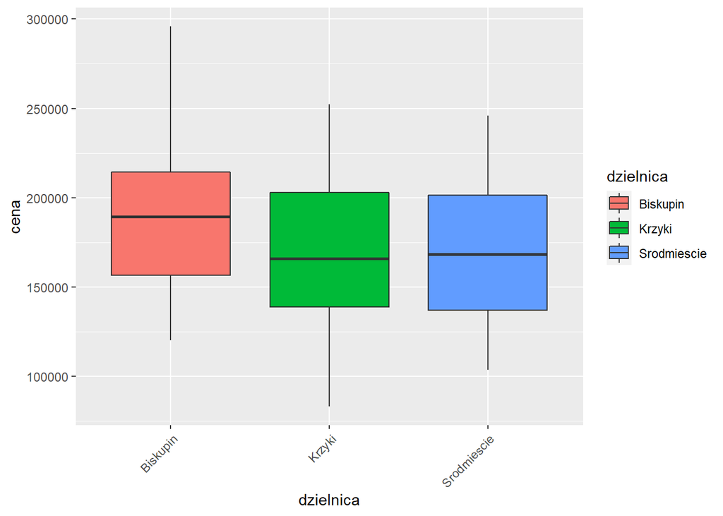

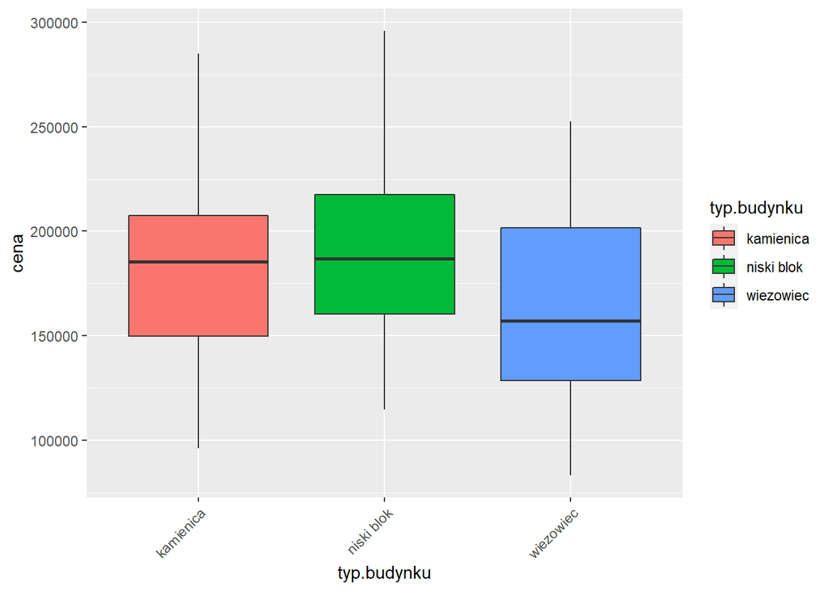

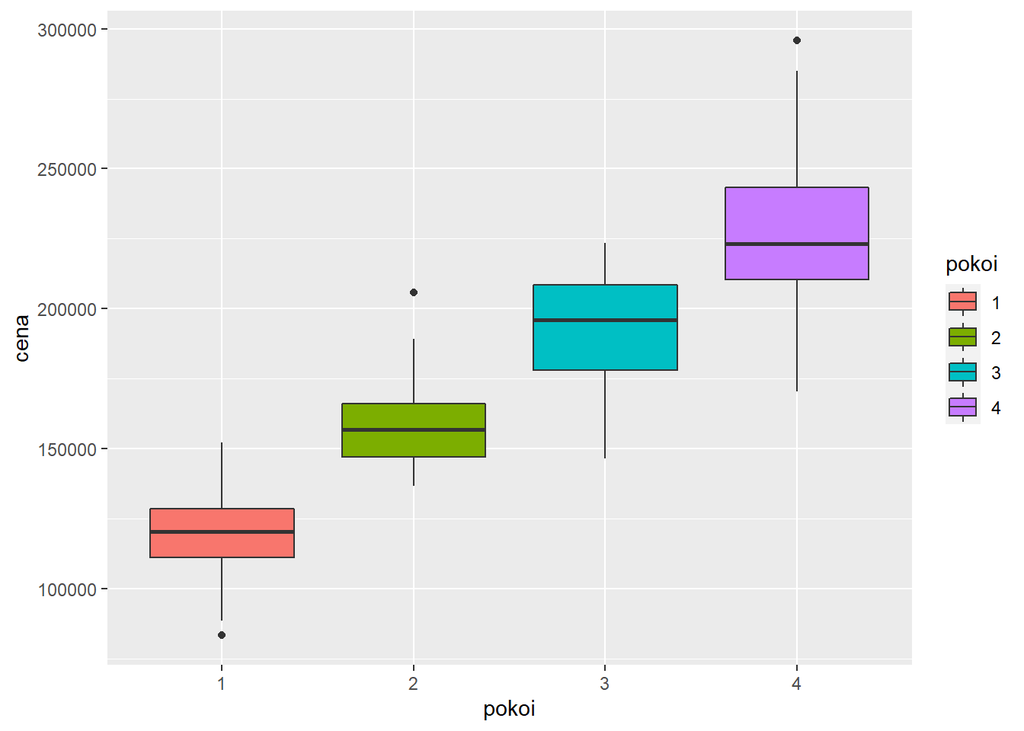

#### Połączenie zmiennej ‘dzielnica’ i ‘typ.budynku’:

| cena | pokoi | dzielnica | typ.budynku | Miejsce |
| --- | --- | --- | --- | --- |
| 226298.17 | 4 | Krzyki | wiezowiec | Krzyki_wiezowiec |
| 128121.35 | 1 | Biskupin | wiezowiec | Biskupin_wiezowiec |
| 118333.42 | 1 | Srodmiescie | wiezowiec | Srodmiescie_wiezowiec |
| 202064.16 | 4 | Srodmiescie | wiezowiec | Srodmiescie_wiezowiec |
| 130303.00 | 1 | Krzyki | wiezowiec | Krzyki_wiezowiec |
| 156241.89 | 2 | Biskupin | wiezowiec | Biskupin_wiezowiec |
| 186732.01 | 2 | Biskupin | kamienica | Biskupin_kamienica |
| 98925.66 | 1 | Krzyki | kamienica | Krzyki_kamienica |
| 193186.71 | 3 | Srodmiescie | wiezowiec | Srodmiescie_wiezowiec |
| 116306.58 | 1 | Krzyki | wiezowiec | Krzyki_wiezowiec |
| 200661.77 | 3 | Biskupin | kamienica | Biskupin_kamienica |
| 120513.56 | 1 | Srodmiescie | kamienica | Srodmiescie_kamienica |
| 165908.86 | 3 | Krzyki | kamienica | Krzyki_kamienica |
| 149856.60 | 2 | Krzyki | kamienica | Krzyki_kamienica |
| 136640.17 | 2 | Srodmiescie | kamienica | Srodmiescie_kamienica |
| 143616.79 | 2 | Krzyki | wiezowiec | Krzyki_wiezowiec |
| 146439.27 | 2 | Biskupin | wiezowiec | Biskupin_wiezowiec |
| 158608.89 | 2 | Krzyki | niski blok | Krzyki_niski blok |
| 204529.65 | 3 | Srodmiescie | kamienica | Srodmiescie_kamienica |
| 186816.07 | 4 | Krzyki | kamienica | Krzyki_kamienica |
| 172528.26 | 3 | Biskupin | wiezowiec | Biskupin_wiezowiec |
| 245845.93 | 4 | Srodmiescie | niski blok | Srodmiescie_niski blok |
| 123690.76 | 1 | Biskupin | wiezowiec | Biskupin_wiezowiec |
| 149943.62 | 2 | Srodmiescie | kamienica | Srodmiescie_kamienica |
| 149948.18 | 2 | Srodmiescie | kamienica | Srodmiescie_kamienica |
| 214461.62 | 3 | Biskupin | niski blok | Biskupin_niski blok |
| 199465.03 | 3 | Biskupin | kamienica | Biskupin_kamienica |
| 93055.36 | 1 | Krzyki | wiezowiec | Krzyki_wiezowiec |
| 140947.96 | 2 | Krzyki | wiezowiec | Krzyki_wiezowiec |
| 214379.62 | 3 | Krzyki | wiezowiec | Krzyki_wiezowiec |

[output cut: 170 more lines]

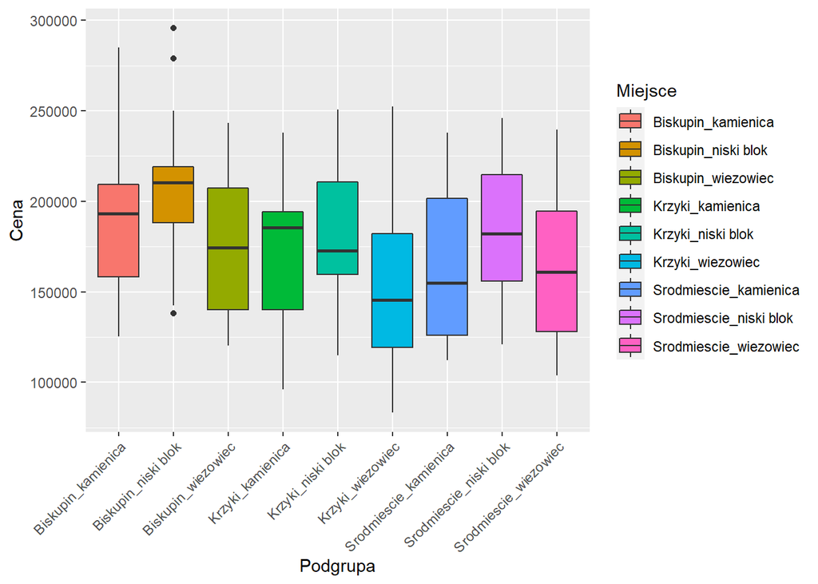

# Rodzaje modeli:

1. Model addytywny (bez interakcji) - model, w którym poszczególne źródła zmienności (zmienne jakościowe) nie zależą od siebie.
2. Model z interakcjami - model, w którym wynikowa wartość badanej cechy jest złożeniem efektów jaki wywołuje każdy czynnik z osobna oraz interakcji tych czynników.

#### Ocena modelu - wykres interakcji:

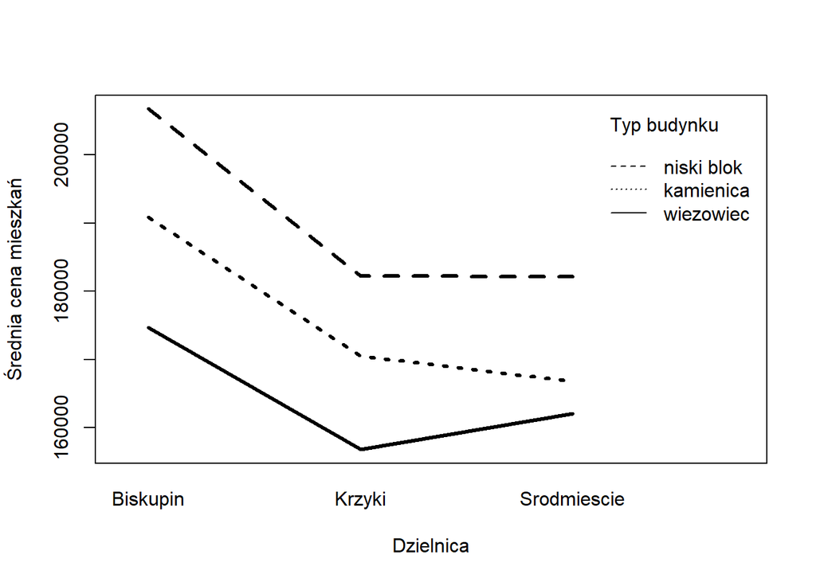

```r
library(stats)
interaction.plot(mieszkania$dzielnica, mieszkania$typ.budynku, mieszkania$cena,
                 ylab= "Średnia cena mieszkań", xlab="Dzielnica", trace.label="Typ budynku", lwd=3)
```

# Model ANOVA - założenia

1. Zmienna zależna ma wartości na skali przedziałowej
2. Spełniona I i II zasada randomizacji
3. Niezależność pomiarów
4. Dane w każdej podgrupie mają rozkład normalny
5. Wariancje w podgrupach są równe

### Analiza normalności w podgrupach

Test Jarque-Bera H0: dane mają rozkład normalny

```r
tapply(mieszkania$cena, mieszkania$Miejsce, jarque.bera.test)
```

```
## $Biskupin_kamienica
##
##  Jarque Bera Test
##
## data:  X[[i]]
## X-squared = 0.99932, df = 2, p-value = 0.6067
##
##
## $`Biskupin_niski blok`
##
##  Jarque Bera Test
##
## data:  X[[i]]
## X-squared = 0.38991, df = 2, p-value = 0.8229
##
##
## $Biskupin_wiezowiec
##
##  Jarque Bera Test
##
## data:  X[[i]]
## X-squared = 1.4898, df = 2, p-value = 0.4748
##
##
## $Krzyki_kamienica
##
##  Jarque Bera Test
##
## data:  X[[i]]
## X-squared = 1.1934, df = 2, p-value = 0.5506
##
##
## $`Krzyki_niski blok`
##
##  Jarque Bera Test
##
## data:  X[[i]]
## X-squared = 0.83517, df = 2, p-value = 0.6586
##
##
```

[output cut: 15 more lines]

```
##
## $`Srodmiescie_niski blok`
##
##  Jarque Bera Test
##
## data:  X[[i]]
## X-squared = 0.8669, df = 2, p-value = 0.6483
##
##
## $Srodmiescie_wiezowiec
##
##  Jarque Bera Test
##
## data:  X[[i]]
## X-squared = 0.7707, df = 2, p-value = 0.6802
```

```r
tapply(mieszkania$cena, mieszkania$dzielnica, jarque.bera.test)
```

```
## $Biskupin
##
##  Jarque Bera Test
##
## data:  X[[i]]
## X-squared = 1.3935, df = 2, p-value = 0.4982
##
##
## $Krzyki
##
##  Jarque Bera Test
##
## data:  X[[i]]
## X-squared = 2.9128, df = 2, p-value = 0.2331
##
##
## $Srodmiescie
##
##  Jarque Bera Test
##
## data:  X[[i]]
## X-squared = 2.7196, df = 2, p-value = 0.2567
```

```r
tapply(mieszkania$cena, mieszkania$typ.budynku, jarque.bera.test)
```

```
## $kamienica
##
##  Jarque Bera Test
##
## data:  X[[i]]
## X-squared = 0.71735, df = 2, p-value = 0.6986
##
##
## $`niski blok`
##
##  Jarque Bera Test
##
## data:  X[[i]]
## X-squared = 0.899, df = 2, p-value = 0.6379
##
##
## $wiezowiec
##
##  Jarque Bera Test
##
## data:  X[[i]]
## X-squared = 3.2427, df = 2, p-value = 0.1976
```

### Analiza wariancji w podgrupach

Test Bartletta (podgrupy są różnoliczne; spełnione jest założenie o rozkładzie normalnym w podgrupach)  
H0: wariancje w podgrupach są jednolite

```r
bartlett.test(cena ~ Miejsce, data=mieszkania)
```

```
##
##  Bartlett test of homogeneity of variances
##
## data:  cena by Miejsce
## Bartlett's K-squared = 2.5577, df = 8, p-value = 0.959
```

```r
bartlett.test(cena ~ dzielnica, data=mieszkania)
```

```
##
##  Bartlett test of homogeneity of variances
##
## data:  cena by dzielnica
## Bartlett's K-squared = 1.3075, df = 2, p-value = 0.5201
```

```r
bartlett.test(cena ~ typ.budynku, data=mieszkania)
```

```
##
##  Bartlett test of homogeneity of variances
##
## data:  cena by typ.budynku
## Bartlett's K-squared = 0.13192, df = 2, p-value = 0.9362
```

# Model ANOVA (bez interakcji)

H0: Wybrany efekt nie wpływa istotnie na badaną zmienną

Testowane hipotezy:

1. Średnie wartości cen w podgrupach utworzonych przez zmienną dzielnica są takie same.
2. Średnie wartości cen w podgrupach utworzonych przez zmienną typ.budynku są takie same.

```r
library(stats)
model <- aov(cena ~ dzielnica + typ.budynku, data = mieszkania)
summary(model)
```

```
##              Df    Sum Sq   Mean Sq F value  Pr(>F)
## dzielnica     2 1.800e+10 8.998e+09   5.340 0.00552 **
## typ.budynku   2 2.272e+10 1.136e+10   6.741 0.00148 **
## Residuals   195 3.286e+11 1.685e+09
## ---
## Signif. codes:  0 '***' 0.001 '**' 0.01 '*' 0.05 '.' 0.1 ' ' 1
```

## Analiza post-hoc

Analiza post-hoc - pomaga zweryfikować, które średnie w grupach różnią się znacząco, a które nie.

Test Tuckey’a - test wielokrotnych porównań

```r
library(stats)
TukeyHSD(model)
```

```
##   Tukey multiple comparisons of means
##     95% family-wise confidence level
##
## Fit: aov(formula = cena ~ dzielnica + typ.budynku, data = mieszkania)
##
## $dzielnica
##                            diff       lwr        upr     p adj
## Krzyki-Biskupin      -21321.019 -37555.96 -5086.0772 0.0062305
## Srodmiescie-Biskupin -18350.541 -36026.45  -674.6339 0.0398520
## Srodmiescie-Krzyki     2970.478 -13965.06 19906.0175 0.9098016
##
## $typ.budynku
##                           diff        lwr       upr     p adj
## niski blok-kamienica  13451.96  -3962.715 30866.634 0.1643361
## wiezowiec-kamienica  -12138.74 -28804.621  4527.141 0.2002204
## wiezowiec-niski blok -25590.70 -42109.178 -9072.221 0.0009473
```

Wnioski:

- Ceny pomiędzy dzielnicami Krzyki-Biskupin i Srodmiescie-Biskupin różnią się zdecydowanie.
- Ceny mieszkań w dzielnicach Krzyki i Srodmiescie są niższe niż w dzielnicy Biskupin.
- Znaczną różnicę cenową można zauważyć pomiędzy mieszkaniami w wiezowcach a niskich blokach.
- Pozostałe różnice dla kombinacji dzielnicy (Srodmiescie-Krzyki) i osobno kombinacji typu budynku (niski blok-kamienica, wiezowiec-kamienica) są nieistotne.

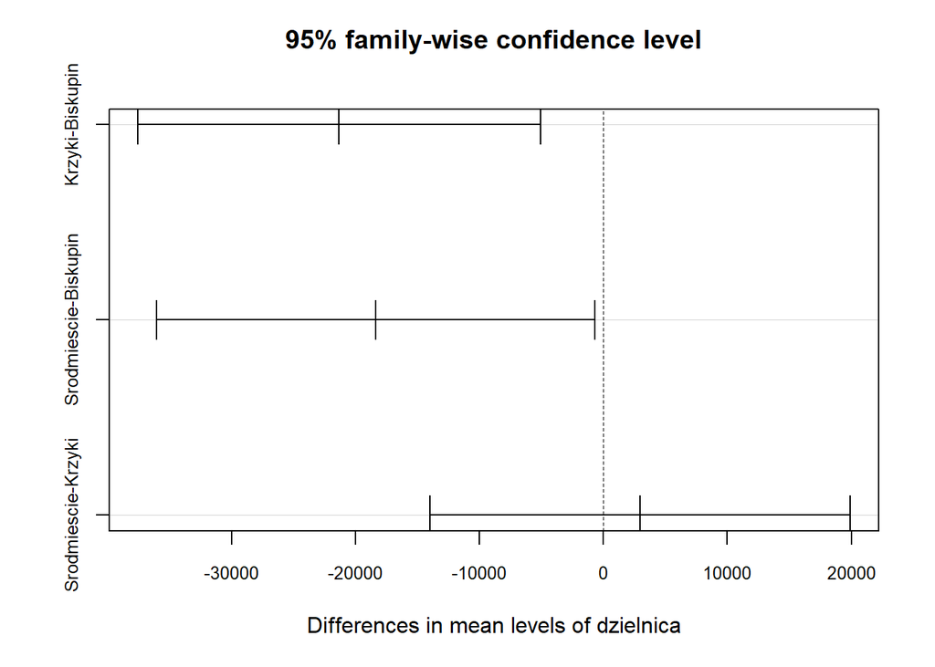

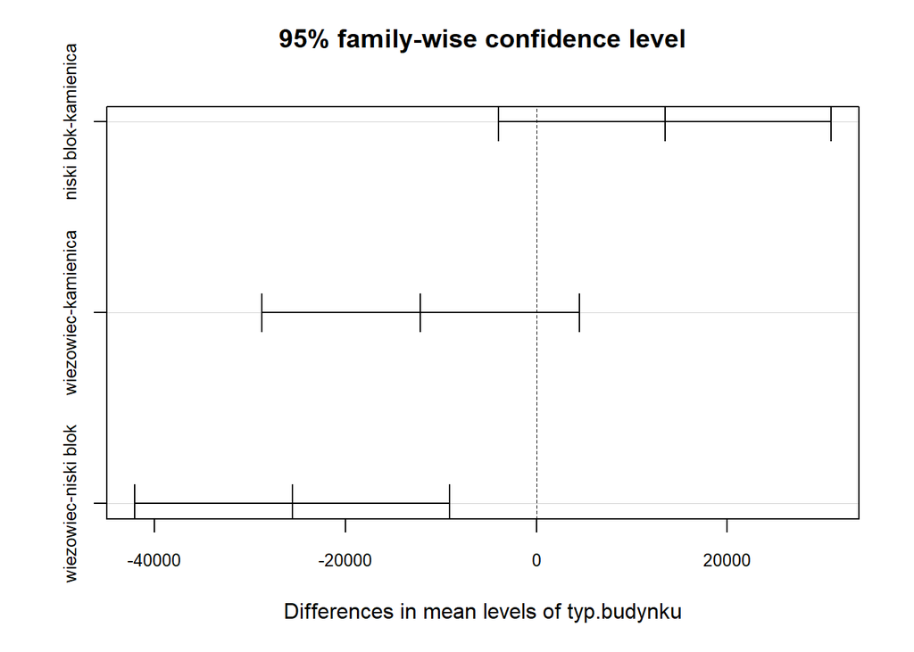

```r
plot(TukeyHSD(model), cex.axis = 0.8)
```

#### Porównanie wyników z początkowymi wykresami:

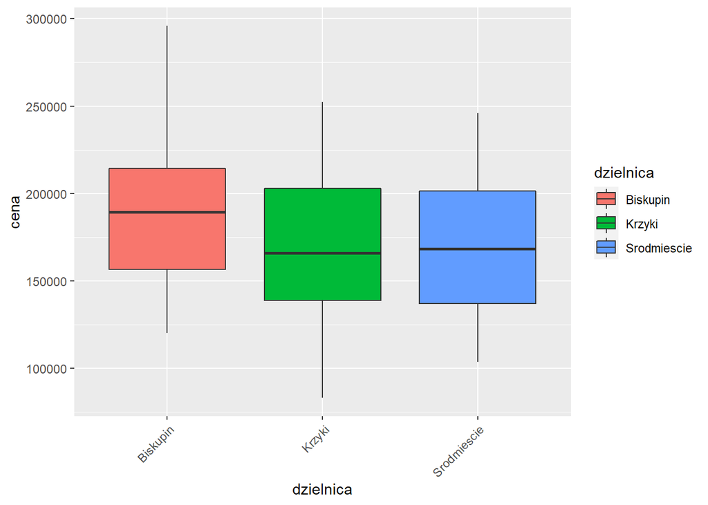

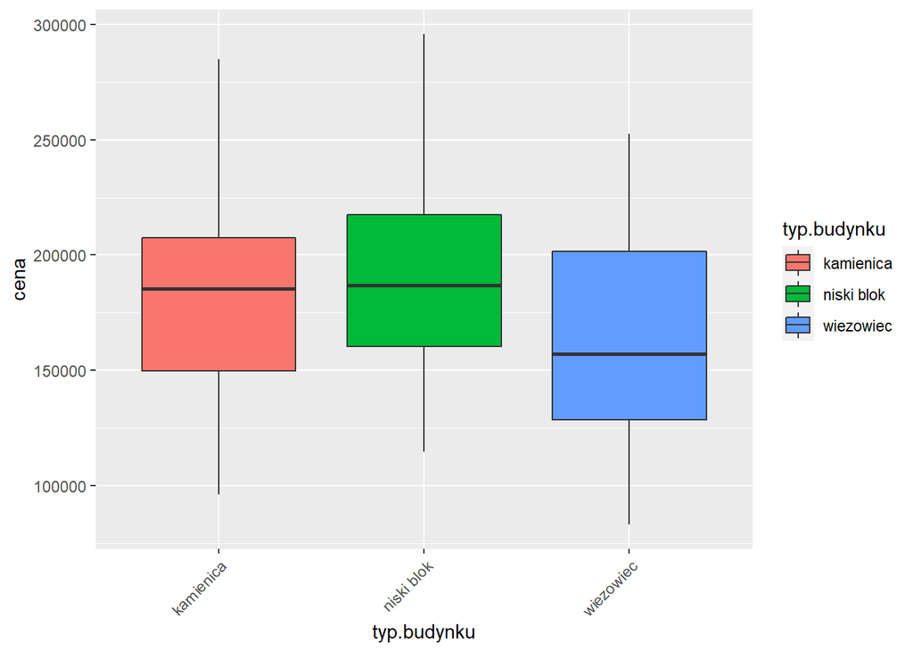

# Model ANOVA (z interakcjami)

H0: Wybrany efekt nie wpływa istotnie na badaną zmienną

Testowane hipotezy:

1. Średnie wartości cen w podgrupach utworzonych przez zmienną dzielnica są takie same.
2. Średnie wartości cen w podgrupach utworzonych przez zmienną typ.budynku są takie same.
3. Średnie wartości cen w podgrupach utworzonych przez zmienne typ.budynku i dzielnica są takie same.

```r
model <- aov(cena ~ dzielnica*typ.budynku, data = mieszkania)
summary(model)
```

```
##                        Df    Sum Sq   Mean Sq F value  Pr(>F)
## dzielnica               2 1.800e+10 8.998e+09   5.246 0.00605 **
## typ.budynku             2 2.272e+10 1.136e+10   6.623 0.00166 **
## dzielnica:typ.budynku   4 9.953e+08 2.488e+08   0.145 0.96499
## Residuals             191 3.276e+11 1.715e+09
## ---
## Signif. codes:  0 '***' 0.001 '**' 0.01 '*' 0.05 '.' 0.1 ' ' 1
```

Wniosek:

- Brak efektu interakcji (łączego wpływu działania zmiennych określających typ budynku oraz dzielnicę)